# Lab 8: Searching for Efficiency

Author

Eva Moylan

Published

November 16, 2024

```r
library(tidyverse)
library(here)
library(kableExtra)
```

For this week’s lab, we will be revisiting questions from previous lab assignments, with the purpose of using functions from the `map()` family to iterate over certain tasks. To do this, we will need to load in the data from Lab 2, Lab 3, and Lab 7. I’ve included **all** three datasets in the `data` folder, so all you need to do is read them in. 🙃

```r
# Data from Lab 2
surveys <- read_csv(here::here("data", "surveys.csv"))

# Data from Lab 3
evals <- read_csv(here::here("data", "teacher_evals.csv")) |>
  rename(sex = gender)

# Data from Lab 7
fish <- read_csv(here::here("data", "BlackfootFish.csv"))
```

## Lab 2

First up, we’re going to revisit Question 3 from Lab 2. This question asked:

> What are the data types of the variables in this dataset?

**1. Using `map_chr()`, produce a nicely formatted table of the data type of each variable in the `surveys` dataset.** Specifically, the table should have 15 columns, one for each variable, with the datatype of that variable immediately below it’s name.

```r
tibble(Variable = names(surveys),
       Data_Type = map_chr(.x = surveys,
                           .f = ~ typeof(.x)
                           )
       ) |>
  pivot_wider(names_from = Variable,
              values_from = Data_Type) |>
  knitr::kable("html",
               align = "c") |>
  #I used the w3schools' Bootstrap Page to figure out how to do borders
  kable_styling(bootstrap_options = "bordered")
```

| record_id | month | day | year | plot_id | species_id | sex | hindfoot_length | weight | date | day_of_week | plot_type | genus | species | taxa |
| --- | --- | --- | --- | --- | --- | --- | --- | --- | --- | --- | --- | --- | --- | --- |
| double | double | double | double | double | character | character | double | double | double | character | character | character | character | character |

## Lab 3

Now, were on to Lab 3 where we will revisit two questions.

In the original version of Lab 3, Question 5 asked you to:

> Change data types in whichever way you see fit (e.g., is the instructor ID really a numeric data type?)

**2. Using `map_at()`, convert the `teacher_id`, `weekday`, `academic_degree`, `seniority`, and `gender` columns to factors.** Hint: You will need to use `bind_cols()` to transform the list output back into a data frame.

```r
evals <- evals |>
  map_at(.at = c("teacher_id",
                 "weekday",
                 "academic_degree",
                 "seniority",
                 "gender"),
         .f = as.factor) |>
  bind_cols()

#Now output the new types
tibble(Variable = names(evals),
       Data_Type = map_chr(.x = evals,
                           .f = ~ typeof(.x)
                           )
       ) |>
  pivot_wider(names_from = Variable,
              values_from = Data_Type) |>
  knitr::kable("html",
               align = "c") |>
  kable_styling(bootstrap_options = "bordered")
```

| course_id | teacher_id | question_no | no_participants | resp_share | SET_score_avg | stud_grade_avg | stud_grade_std | stud_grade_var_coef | percent_failed | stud_grade_avg_cur | stud_grade_std_cur | stud_grade_var_coef_cur | percent_failed_cur | class_duration | weekday | time_of_day | SET_score_1sem | maximum_score | academic_degree | seniority | sex |
| --- | --- | --- | --- | --- | --- | --- | --- | --- | --- | --- | --- | --- | --- | --- | --- | --- | --- | --- | --- | --- | --- |
| character | integer | double | double | double | double | double | double | double | double | double | double | double | double | double | integer | character | double | double | integer | integer | character |

Next up, we’re going revisit Question 7 which asked:

> What are the demographics of the instructors in this study? Investigate the variables `academic_degree`, `seniority`, and `sex` and summarize your findings in ~3 complete sentences.

Many people created **multiple** tables of counts for each of these demographics, but in this exercise we are going to create **one** table with every demographic.

**3. Using `pivot_longer()` and `pivot_wider()`, recreate the table below.**

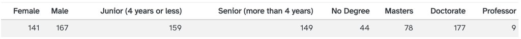

**Tip**

I’m using the `sen_level` classification from Challenge 3

- `"junior"` = `seniority` is 4 or less (inclusive)
- `"senior"` = `seniority` is more than 4

```r
evals |>
  distinct(teacher_id,
           .keep_all = TRUE) |>
  select(teacher_id,
         sex,
         seniority,
         academic_degree) |>
  mutate(seniority = if_else(as.numeric(seniority) <= 4,
                             #Can't apply this to a factor, so convert to numeric
                             "Junior (4 years or less)",
                             "Senior (more than 4 years)")
         ) |>
  pivot_longer(cols = -teacher_id,
               names_to = "teacher_attribute",
               values_to = "teacher_status") |>
  count(teacher_attribute, teacher_status) |>
  pivot_wider(id_cols = -teacher_attribute,
              names_from = teacher_status,
              values_from = n) |>
  select(female,
         male,
         'Junior (4 years or less)',
         'Senior (more than 4 years)',
         no_dgr,
         ma,
         dr,
         prof) |>
  rename(Female = female,
         Male = male,
         'No Degree' = no_dgr,
         Masters = ma,
         Doctorate = dr,
         Professor = prof) |>
  knitr::kable("html") |>
  kable_styling(bootstrap_options = "striped")
```

| Female | Male | Junior (4 years or less) | Senior (more than 4 years) | No Degree | Masters | Doctorate | Professor |
| --- | --- | --- | --- | --- | --- | --- | --- |
| 141 | 167 | 159 | 149 | 44 | 78 | 177 | 9 |

**Tip**

If you are interested in exploring my table formatting, I specifically used the `kable()` function from the **knitr** package to first get an HTML table. Then I styled that table using the `kable_styling()` function from the **kableExtra** package.

## Lab 7

For our last problem, we will revisit a question from the most recent lab. Question 1 asked you to use `across()` to make a table which summarized:

> What variable(s) have missing values present?  
> How many observations have missing values?

**4. Using `map_int()`, produce a nicely formatted table of the number of missing values for each variable in the `fish` data.**

```r
tibble(Variable = names(fish),
       NA_Count = map_int(.x = fish,
                          .f = ~sum(is.na(.x))
                          )
       ) |>
  mutate(Variable = str_replace(string = Variable,
                                pattern = "^[a-z]",
                                replace = toupper)) |>
#str_replace( ) description used to figure out 'toupper' replaces letters with uppercase
  pivot_wider(names_from = Variable,
              values_from = NA_Count) |>
  knitr::kable("html",
               align = "c",
               caption = "Table 1: Frequency of missing values in the Blackfoot River Trout dataset across study years 1988-2006.") |>
  #kable() description used to find arguments
  kable_styling(bootstrap_options = "striped")
```

Table 1: Frequency of missing values in the Blackfoot River Trout dataset across study years 1988-2006.

| Trip | Mark | Length | Weight | Year | Section | Species |
| --- | --- | --- | --- | --- | --- | --- |
| 0 | 0 | 0 | 1796 | 0 | 0 | 0 |